# Potomac River Benthic Macroinvertebrates

Zachary M. Smith

August 1, 2018

Load necessary packages.

```r
library(tidyverse)
library(vegan)
library(toolbox)
library(mmir)
```

Import the taxonomic hierarchy table from the **mmir** package. If any of the taxonomic columns contain an `NA`, the `fill_taxa()` function will fill the cell with the cell located to the left. For example, if Chironomidae taxa were only identified to the family-level, then the `tribe` and `genus` columns will be filled originally be represented by `NA` and subsequently filled with “chironomidae.”

```r
master <- mmir::hier.fwmi %>%
  toolbox::prep_df() %>%
  fill_taxa(final_id, phylum:species) %>%
  select(final_id, phylum, class, order, family, tribe, genus)
```

Import the taxonomic data and prepare the data for analysis. `reach` and `bank` are extracted from the `station_id`.

```r
org.df <- data.table::fread(file.path(rprojroot::find_rstudio_root_file(),
                                      "data/JIM_C_DATA_3.csv"))%>%
  toolbox::prep_df() %>%
  separate(station_id, c("station_id", "count")) %>%
  mutate(date = as.Date(date, "%m_%d_%Y"),
         year = lubridate::year(date),
         reach = str_sub(station_id, 1, 2),
         bank = str_sub(station_id, str_count(station_id) - 1, str_count(station_id))) %>%
  select(reach, bank, year, final_id, reporting_value) %>%
  unite(unique_id, c("reach", "bank", "year"), remove = FALSE) %>%
  unite(reach_year, c("reach", "year"), remove = FALSE)
```

[ITIS](https://www.itis.gov/) was used to construct the **mmir** taxonomic hierarchy table. Therefore, taxonomic data must be consistent with valid taxonomic names in ITIS. Additionally, there were some inconsistencies in the taxonomic rank of some taxa. These taxa were rolled up to the lowest common taxonomic rank.

```r
standard.df <- org.df %>%
  mutate(final_id = case_when(
    final_id == "serratella_deficiens" ~ "teloganopsis",
    final_id == "tvetenia_discoloripes" ~ "chironomidae",
    final_id == "sphaeriidae" ~ "pisidiidae",
    final_id == "turbellaria"  ~ "platyhelminthes",
    final_id == "tubificidae"  ~ "oligochaeta",
    TRUE ~ final_id
  )) %>%
  left_join(master, by = "final_id") %>%
  mutate(
    class = if_else(phylum == "platyhelminthes", "platyhelminthes", class),
    order = case_when(
      class == "oligochaeta" ~ "oligochaeta",
      phylum == "platyhelminthes" ~ "platyhelminthes",
      TRUE ~ order
    ),
    family = case_when(
      class == "oligochaeta" ~ "oligochaeta",
      phylum == "platyhelminthes" ~ "platyhelminthes",
      TRUE ~ family
    ),
    tribe = case_when(
      family == "chironomidae" ~ "chironomidae",
      family == "pisidiidae" ~ "pisidiidae",
      class == "oligochaeta" ~ "oligochaeta",
      phylum == "platyhelminthes" ~ "platyhelminthes",
      TRUE ~ tribe
    ),
    genus = case_when(
      family == "chironomidae" ~ "chironomidae",
      family == "pisidiidae" ~ "pisidiidae",
      class == "oligochaeta" ~ "oligochaeta",
      phylum == "platyhelminthes" ~ "platyhelminthes",
      TRUE ~ genus
    ),
    final_id = case_when(
      family == "chironomidae" ~ "chironomidae",
      family == "pisidiidae" ~ "pisidiidae",
      class == "oligochaeta" ~ "oligochaeta",
      phylum == "platyhelminthes" ~ "platyhelminthes",
      TRUE ~ final_id
    )
  ) %>%
  group_by_at(vars(-reporting_value)) %>%
  summarize(count = sum(reporting_value)) %>%
  ungroup()
```

## Non-Metric Multi-Dimensional Scaling (NMDS)

Summarize all of the data at the genus-level for each sample (`unique_id`).

```r
gen.df <- standard.df %>%
  select(unique_id, year,  genus, count) %>%
  separate(unique_id, c("station_id", "samp_count", "date"), remove = FALSE) %>%
  mutate(reach = str_sub(station_id, 1, 2),
         bank = str_sub(station_id, str_count(station_id) - 1, str_count(station_id))) %>%
  unite(reach_year, c("reach", "year"), remove = FALSE) %>%
  unite(reach_bank_year, c("reach", "bank", "year"), remove = FALSE)
```

Summarize the data by `reach` and `year` at the genus-level.

```r
year.df <- gen.df %>%
  group_by(unique_id, reach, year, reach_year, bank, genus) %>%
  summarize(count = sum(count)) %>%
  ungroup() %>%
  spread(genus, count, fill = 0)
```

This function calculates the NMDS using the **vegan** package.

```r
run_nmds <- function(x, k) {
  set.seed(101582) #sample(1:10^6, 1)

  y <- x %>%
    dplyr::select_if(is.numeric) %>%
    dplyr::select(-year)
  # comm.mat  <- as.matrix(y)
  # rownames(comm.mat) <- y$unique_id
  nmds <- invisible(vegan::metaMDS(y, k = k, trymax = 1000))
}
```

This function will standardize the NMDS Plots.

```r
plot_nmds <- function(x, group, k = 2) {
  x <- x %>%
    dplyr::arrange(!!rlang::sym(group))

  nmds <- invisible(run_nmds(x, k))

  dimnames(nmds$points)[[1]] <- x$unique_id

  take  <- c(1, 2)

  group.vec <- x %>%
    dplyr::pull(!!rlang::sym(group))
  color.length <- length(unique(group.vec))
  viridis.vec <- viridis::viridis_pal()(color.length)

  x <- x %>%
    mutate(
      group = as.factor(!!rlang::sym(group)),
      num = as.numeric(group),
      color = viridis.vec[as.numeric(group)])

  {
    plot(
      nmds,
      choices = take,
      # scaling = "symmetric",
      dis = "sp",
      type = "n",
      xlim = c(-1, 1),
      ylim = c(-0.8, 0.8)
    )

    with(x, ordiellipse(
      nmds,
      groups = year,
      choices = take,
      # group.vec,
      kind = "sd",
      conf = 0.95,
      draw = "polygon",
      col = viridis.vec,
      label = FALSE
    )
    )

    with(x,  points(
      nmds,
      display = "sites",
      col = "black",
      bg = color,
      cex = 1.5,
      pch = 22
    ))

    legend(
      1.0,
      0.7,
      legend = unique(group.vec),
      col = viridis::viridis_pal()(color.length),
      lty = "solid",
      lwd = 10
    )

    text(
      1.3,
      0.1,
      paste("k =", k,
            "\n Stress:", round(nmds$stress, 2)
      )
    )
    }

}
```

### All Reaches by Year

```
## Square root transformation
## Wisconsin double standardization
## *** Solution reached
```

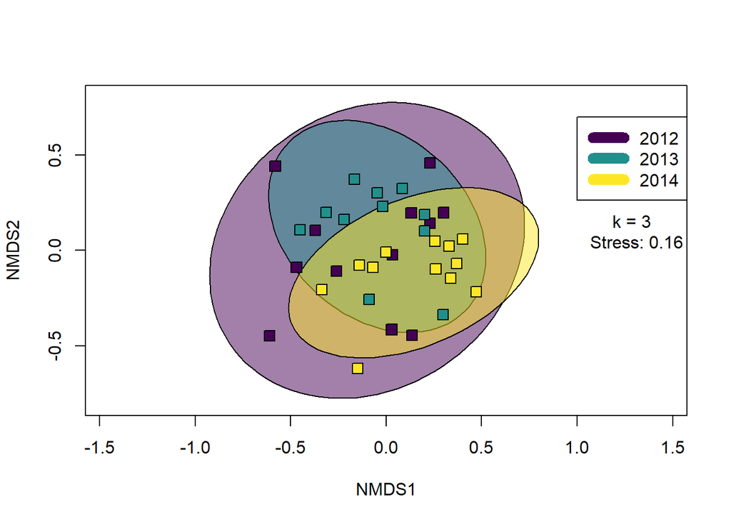

```r
year.df %>%
  plot_nmds("year", k = 3)
```

### Knoxville by Year

```
## Square root transformation
## Wisconsin double standardization
## *** Solution reached
```

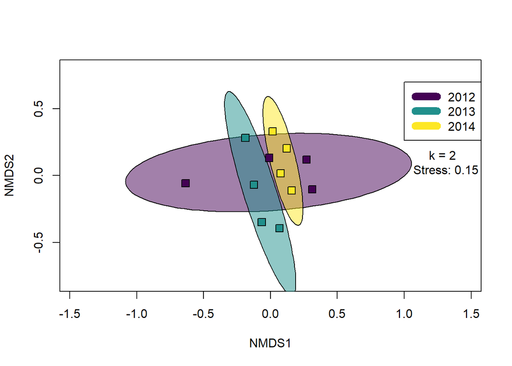

```r
year.df %>%
  filter(reach == "kx") %>%
  plot_nmds("year", k = 2)
```

### Carderock by Year

```
## Square root transformation
## Wisconsin double standardization
## *** Solution reached
```

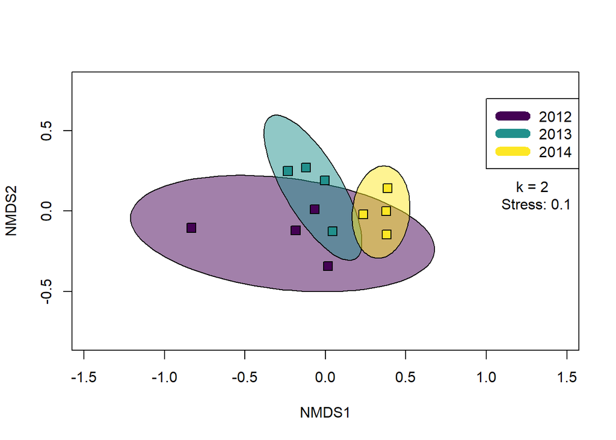

```r
year.df %>%
  filter(reach == "cr") %>%
  plot_nmds("year", k = 2)
```

### Little Falls by Year

```
## Square root transformation
## Wisconsin double standardization
## *** Solution reached
```

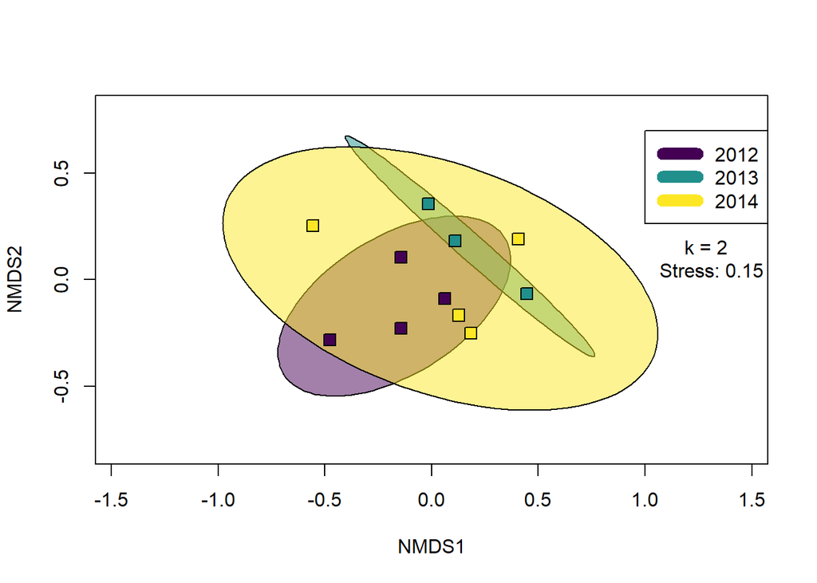

```r
year.df %>%
  filter(reach == "lf") %>%
  plot_nmds("year", k = 2)
```

Generate a metric key. This data frame will represent sample information, like `reach`, `bank`, and `year`, that the metric values will be appended to.

```r
metrics.key <- standard.df %>%
  select(unique_id, reach_year, reach, bank, year) %>%
  distinct()
```

### Calculate Metrics

Calculate the metrics of interest using the **mmir** package functions.

```r
metrics.df <- metrics.key %>%
  mutate(rich = taxa_rich(standard.df, unique_id, genus),
         rich_ephemeroptera = taxa_rich(standard.df, unique_id, order, genus, "ephemeroptera"),
         rich_trichoptera = taxa_rich(standard.df, unique_id, order, genus, "trichoptera"),
         rich_diptera = taxa_rich(standard.df, unique_id, order, genus, "diptera"),
         pct_chironomidae = taxa_pct(standard.df, unique_id, count,
                                     taxon.col = family, taxon = "chironomidae"),
         pct_corbiculidae = taxa_pct(standard.df, unique_id, count,
                                     taxon.col = family, taxon = "corbiculidae"),
         pct_elmidae = taxa_pct(standard.df, unique_id, count,
                                taxon.col = family, taxon = "elmidae"),
         pct_hydropsychidae = taxa_pct(standard.df, unique_id, count,
                                       taxon.col = family, taxon = "hydropsychidae"),
         pct_ephemeroptera = taxa_pct(standard.df, unique_id, count,
                                      taxon.col = order, taxon = "ephemeroptera"),
         pct_plecoptera = taxa_pct(standard.df, unique_id, count,
                                   taxon.col = order, taxon = "plecoptera"),
         pct_trichoptera = taxa_pct(standard.df, unique_id, count,
                                    taxon.col = order, taxon = "trichoptera"),
         pct_ept = taxa_pct(standard.df, unique_id, count,
                            taxon.col = order, taxon = c("ephemeroptera",
                                                         "plecoptera",
                                                         "trichoptera"))
  )
```

Identify the metrics of interest and the reaches of interest.

```r
metrics.vec <- c("rich", "rich_ephemeroptera", "rich_trichoptera",
                 "rich_diptera", "pct_chironomidae",
                 "pct_corbiculidae",
                 "pct_elmidae", "pct_hydropsychidae", "pct_ephemeroptera",
                 "pct_plecoptera", "pct_trichoptera", "pct_ept")
reach.vec <- unique(metrics.df$reach)
```

### Kruskal-Wallis and post hoc Dunn’s Test

For each metric, run the Kruskal-Wallis and post hoc Dunn’s test to compare the values from each reaches collection year. The values are stored in a dataframe. Keep in mind that the Kruskal-Wallis p-value (`kruskal_p`) must be < α before it is appropriate to review the Dunn’s test adjusted p-value (`dunn_adjusted_p`).

```r
dunn.df <- map_df(metrics.vec, function(metric.i){
  map_df(reach.vec, function(reach.i) {
    metrics.sub <- metrics.df %>%
      filter(reach  == reach.i) %>%
      mutate(reach_year = as.factor(reach_year)) %>%
      rename(metric = metric.i)

    kruskal.df <- kruskal.test(metric ~ as.factor(reach_year), data = metrics.sub) %>%
      broom::tidy() %>%
      mutate(metric = metric.i,
             reach = reach.i) %>%
      select(reach, metric, everything())

    final.df <- dunn.test::dunn.test(metrics.sub$metric, metrics.sub$reach_year)
    final.df <- tibble(
      metric = metric.i,
      kruskal_p = kruskal.df$p.value,
      kruskal_stat = kruskal.df$statistic,
      dunn_comparisons = final.df$comparisons,
      dunn_p_adjusted = final.df$P.adjusted,
      dunn_p_value = final.df$P,
      dunn_z_score = final.df$Z,
      dunn_chi2 = final.df$chi2
    )
  })
})
```

```
##   Kruskal-Wallis rank sum test
##
## data: x and group
## Kruskal-Wallis chi-squared = 5.177, df = 2, p-value = 0.08
##
##
##                            Comparison of x by group
##                                 (No adjustment)
## Col Mean-|
## Row Mean |    cr_2012    cr_2013
## ---------+----------------------
##  cr_2013 |  -1.137656
##          |     0.1276
##  cr_2014 |   1.137656   2.275312
##          |     0.1276    0.0114*
##
## alpha = 0.05
## Reject Ho if p <= alpha/2
##   Kruskal-Wallis rank sum test
##
## data: x and group
## Kruskal-Wallis chi-squared = 2.0723, df = 2, p-value = 0.35
##
##
##                            Comparison of x by group
##                                 (No adjustment)
## Col Mean-|
## Row Mean |    kx_2012    kx_2013
## ---------+----------------------
##  kx_2013 |  -0.792824
##          |     0.2139
##  kx_2014 |  -1.436995  -0.644170
##          |     0.0754     0.2597
##
## alpha = 0.05
## Reject Ho if p <= alpha/2
##   Kruskal-Wallis rank sum test
##
## data: x and group
## Kruskal-Wallis chi-squared = 2.0547, df = 2, p-value = 0.36
```

[output cut: 593 more lines]

```
## Kruskal-Wallis chi-squared = 0.053, df = 2, p-value = 0.97
##
##
##                            Comparison of x by group
##                                 (No adjustment)
## Col Mean-|
## Row Mean |    lf_2012    lf_2013
## ---------+----------------------
##  lf_2013 |  -0.131590
##          |     0.4477
##  lf_2014 |   0.106600   0.230283
##          |     0.4576     0.4089
##
## alpha = 0.05
## Reject Ho if p <= alpha/2
```

```r
DT::datatable(dunn.df)
```

|  | metric | kruskal_p | kruskal_stat | dunn_comparisons | dunn_p_adjusted | dunn_p_value | dunn_z_score | dunn_chi2 |
| --- | --- | --- | --- | --- | --- | --- | --- | --- |
| 1 | rich | 0.0751309166613481 | 5.17704626334519 | cr_2012 - cr_2013 | 0.127632040590359 | 0.127632040590359 | -1.13765617206443 | 5.1770462633452 |
| 2 | rich | 0.0751309166613481 | 5.17704626334519 | cr_2012 - cr_2014 | 0.127632040590359 | 0.127632040590359 | 1.13765617206443 | 5.1770462633452 |
| 3 | rich | 0.0751309166613481 | 5.17704626334519 | cr_2013 - cr_2014 | 0.0114435997297373 | 0.0114435997297373 | 2.27531234412887 | 5.1770462633452 |
| 4 | rich | 0.354814303788124 | 2.07232142857143 | kx_2012 - kx_2013 | 0.213939903959125 | 0.213939903959125 | -0.792824967172092 | 2.07232142857143 |
| 5 | rich | 0.354814303788124 | 2.07232142857143 | kx_2012 - kx_2014 | 0.0753596711903626 | 0.0753596711903626 | -1.43699525299942 | 2.07232142857143 |
| 6 | rich | 0.354814303788124 | 2.07232142857143 | kx_2013 - kx_2014 | 0.259732508493042 | 0.259732508493042 | -0.644170285827325 | 2.07232142857143 |
| 7 | rich | 0.357960796958067 | 2.05466360856269 | lf_2012 - lf_2013 | 0.434377252878283 | 0.434377252878283 | 0.165240732815986 | 2.05466360856269 |
| 8 | rich | 0.357960796958067 | 2.05466360856269 | lf_2012 - lf_2014 | 0.0903499862563019 | 0.0903499862563019 | 1.33860292774412 | 2.05466360856269 |
| 9 | rich | 0.357960796958067 | 2.05466360856269 | lf_2013 - lf_2014 | 0.141396828021455 | 0.141396828021455 | 1.07406476330391 | 2.05466360856269 |
| 10 | rich_ephemeroptera | 0.40193763736366 | 1.82291666666667 | cr_2012 - cr_2013 | 0.399301622754695 | 0.399301622754695 | -0.255155181539914 | 1.82291666666667 |

[output cut: 98 more lines]

### Boxplots

Transform the dataframe from a wide data format to a long data format.

```r
long.df <- metrics.df %>%
  gather(metric, value, rich:pct_ept)
```

Generate boxplots for each reach and metric. The values are grouped by collection year.

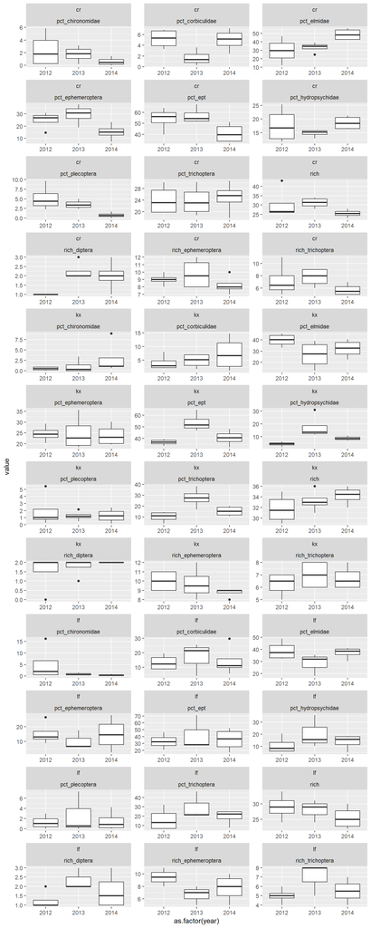

```r
long.df %>%
  ggplot(aes(as.factor(year), value)) +
  geom_boxplot() +
  facet_wrap(~ reach + metric, ncol = 3, scales = "free")
```

### Percentiles of Interest

Calculate the percentiles of interest for each reach and metric. Additionally, a `lower_fence` and `upper_fence` are calculated by multiplying the interquartile range by 1.5 and then either subtracting this values from the 25th percentile or adding this value to the 75th percentile.

```r
percentiles.df <- long.df %>%
  group_by(reach, metric) %>%
  summarize(iqr = IQR(value),
            quant10 = quantile(value, 0.10),
            quant25 = quantile(value, 0.25),
            quant75 = quantile(value, 0.75),
            quant90 = quantile(value, 0.90),
            lower_fence = quant25 - iqr * 1.5,
            upper_fence = quant75 + iqr * 1.5
  ) %>%
  ungroup() %>%
  select(reach, metric, lower_fence, quant10, quant25, quant75, quant90, upper_fence)

DT::datatable(percentiles.df)
```

|  | reach | metric | lower_fence | quant10 | quant25 | quant75 | quant90 | upper_fence |
| --- | --- | --- | --- | --- | --- | --- | --- | --- |
| 1 | cr | pct_chironomidae | -3.24335515342231 | 0.20824274727073 | 0.229500402311462 | 2.54473743946731 | 3.29349338004224 | 6.01759299520109 |
| 2 | cr | pct_corbiculidae | -3.49329552492674 | 0.998618197278912 | 2.28843593358396 | 6.14292357259109 | 6.88615979351067 | 11.9246550311018 |
| 3 | cr | pct_elmidae | 13.3667548437472 | 23.7477273844037 | 31.7831559758205 | 44.060756730536 | 52.8925912796881 | 62.4771578626093 |
| 4 | cr | pct_ephemeroptera | -4.90589929224002 | 14.5190615835777 | 15.5470336115497 | 29.1823222140762 | 32.8750972529774 | 49.635255117866 |
| 5 | cr | pct_ept | 24.5862510502097 | 34.3353420772776 | 44.1935483870968 | 57.2650799450215 | 63.4907765141209 | 76.8723772819086 |
| 6 | cr | pct_hydropsychidae | 5.52957645986072 | 12.946017116524 | 14.4162226382488 | 20.3406534238409 | 21.1594378674823 | 29.2272996022291 |
| 7 | cr | pct_plecoptera | -2.60015102299279 | 0.550006694336591 | 1.47498255949151 | 4.19173828114772 | 5.26845146660815 | 8.26687186363202 |
| 8 | cr | pct_trichoptera | 8.670452359816 | 18.9203423304806 | 19.9099287808965 | 27.4029130616169 | 30.2576122563985 | 38.6423894826974 |
| 9 | cr | rich | 18.875 | 25.1 | 26 | 30.75 | 33.9 | 37.875 |
| 10 | cr | rich_diptera | -0.5 | 1 | 1 | 2 | 2.9 | 3.5 |

[output cut: 26 more lines]